# temp

## 绪论

摘录书中几句有意思的话

1. “没有免费的午餐定理”(NFL)说明脱离具体的问题，空谈什么算法好，毫无意义。
2. 以往机器学习在应用中要取得很好的性能对使用者要求较高，而深度学习只要下功夫调参，把参数调节好性能往往就好。降低了门槛，为机器学习走向工程带来便利。

## 模型评估与选择

在研究对比不同算法的泛化性能时使用测试集，在模型选择和调参时，使用验证集。

### 1. 经验误差与过拟合

- 错误率(error rate)：预测错误样本占总数比例
- 精度(accuracy)：1 - 错误率
- 误差(error)：预测输出与实际输出之间的差异。学习器在训练集上的误差为训练误差或经验误差；在外部数据上的误差叫做泛化误差。
- 过拟合(overfitting)：学习器把训练样本学的太好，以至于将一些非全局的特性都学到了这就导致了泛化能力的下降。主要是由于学习器学习能力太强。过拟合是机器学习所面临的关键障碍，无法彻底避免，只能缓解。
- 模型选择(model selection)：现实任务往往多种学习器选择，或同一学习器，不同参数配置也会产生不同的模型。这就出现了模型选择问题。
- **怎么选择** ？理想的解决方案是对候选模型的泛化误差来评估，然后选泛化误差最小的。**然而**，无法直接获得泛化误差，而训练误差由于过拟合的存在也不合适。所以说怎么选择是个问题，我们在下节讨论。

### 2. 怎么来评估模型：模型的评估方法

那现在就是说了怎么来评估模型好坏从而选择模型呢？

ANS:通常，通过实验测试来对学习器的泛化误差进行评估从而进行模型选择。为此需要一个验证集，来测试学习器对新样本的判别能力，以验证集上的验证误差作为泛化误差的近似。

那怎么产生各种集呢？

ANS:不着急，看下面讲解。

#### 2.1 训练集合测试集的产生

- 留出法(hand-out)：最简单，直接将数据集划分为两个互斥的集合。
  1. 需要注意训练测试的划分要保证数据分布的一致性。
  2. 即便给定了训练集和测试集的样本比例，单次划分的估计结果往往不够稳定，要多次划分求均值作为留出法的评估结果。
  3. 测试集小时，评估结果方差较大；训练集小时，评估结果偏差较大。一般是大约2/3~4/5作为训练，其余做测试。
- 交叉验证法(Cross validation)：现将数据划分为K个大小相似的互斥的子集，然后以k-1个子集的并集作为训练，其余作为测试。这样可以进行K次训练测试，得到K组结果，最终返回K个结果的均值。
  1. 留一法一般被认为比较准确，然而数据集较大时，计算开销难以忍受。
- 自助法(bootstrapping)

  前两种方法由于保留部分样本作为测试，因此实际评估的模型使用的训练集要小。会导致因训练样本规模不同导致的估计偏差。**留一法**还好。为解决这个问题提出了自助法。

  什么是自助法？

  ANS : 给定包含m个样本的数据D,对他进行数据采样产生数据集D'。具体方法是，每次从D中挑一个样本放入D',这样有放回的抽m次，得到了包含m个样本的D'。通过计算，样本在m次中均不被抽到概率为0.368。于是我们将D'作为训练集，始终未被抽到的那些作为测试集。这样实际评估的模型与期望评估的模型都有m个训练样本，而且仍有约占数据总量1/3的数据做测试。这也称为**包外估计**(out-of-bag estimate)。

  什么时候使用该方法？

  ANS：数据集较小，难以有效划分训练测试时很有效。另外该方法可以从数据中产生多个不同训练集，对集成学习也有好处。

  缺点呢？

  ANS：产生的数据集改变了原有数据集的分布，将引入估计偏差。因此，数据足够时留出法和交叉验证使用的多一些。

#### 2.2 选定模型，还要做什么：调参(也是一种模型选择)

**在模型选择完成后，学习算法和参数配置也都选定，此时应该用数据集D重新训练模型，这才是我们的最终模型。**

### 3. 用什么值来评估：模型的性能度量

#### 3.1 回归任务

回归任务中，最常使用的性能就是 **均方误差**(mean squared error) $$E(f;D) = \frac {1}{m}\sum_{i=1}^m(f(x_i)-y_i)^2$$ 另外一个常用的就是$R^2$ $$R^2 = 1-\frac{SSE}{SST}$$ $$SSE = \sum_{i=1}^m(f(x_i)-y_i)^2$$ $$SST = \sum_{i=1}^m(y_i-\overline y)^2$$ 其中SSE(Sum of Squares for Error)。

#### 3.2 分类问题

- 错误率和精度

$$E(f;D) = \frac{1}{m}\sum_{i=1}^mI(f(x_i)\neq y_i)$$$$acc(f;D) = 1-E(f;D)$$

- 查准率、查全率与F1  
  查准率(Precision)：我挑出来的瓜里面有多少是好的（所谓我挑出来的，就是我认为它是好的，也就是所有的预测Positive)  
  查全率(Recall)：所有好的瓜里面我挑出来多少(所谓所有的好瓜即所有的实际Positive)  
  [P =\frac{TP}{TP+FP}] [P =\frac{TP}{TP+FN}]
- F1值
  全了不一定准，准了又不一定全，我们需要一个平衡点这就 是**F1值**(基于查准率和查全率的调和评价) $$F1 = \frac{2\times P\times R}{P+R}$$ 在有些问题中，由于查全率和查准率的重要 程度不同，因此引入了F1的一般形式 $F_{\beta}$，可以定义对查准率和查全率的不同偏好。
  $$F_{\beta} = \frac{(1+\beta^2)\times P\times R}{(\beta^2\times P)+R}$$ 其中 $\beta$ 度量了查全率/查准率的相对重要性。$\beta>1$,说明查全率影响更大，反之，查准率影响更大。
  另外，关于对多次训练/测试计算“宏”和“微”的问题，先算出最终结果再计算平均叫“宏”，先计算中间值平均(如TP等)在计算最终结果叫“微”。
- ROC和AUC
  很多分类器其实产生的是一个实值或概率预测，然后将预测值与设定的分类阈值比较，大于阈值非为正类，小于分为反类。 一般情况下，若重视**查准率**，那就把阈值设大一点，反之设小一点。
  ROC全程“受试者工作特征”(Receiver Operating Characteristic)。其纵轴为**真正例率**(TPR)，横轴为**假正例率**(FPR)。 $$TPR = \frac{TP}{TP+FN}$$ $$FPR = \frac{FP}{TN+FP}$$ 其过程如下：
  - 给定 $m^+$ 个正例和 $m^-$ 个反例
  - 按照预测结果对样例降序排列
  - 把分裂阈值设为最大(将所有结果均预测为反例)，分别求出TPR和FPR。
  - 然后将阈值依次设为每个样例的预测值，依次求出TPR和FPR。

  在求坐标过程中，若前一个点的坐标为(x,y) ，若该点为真正例，则该点坐标为 $(x,y+\frac{1}{m^+})$；若该点为假正例，则该点坐标为 $(x+\frac{1}{m^-},y)$。

  **AUC**是ROC曲线下面积，其考虑的是样本预测的排序质量，等于1减去排序损失。可以通过如下计算公式估算： $$AUC = \frac1{2}\sum_{i=1}^{m-1}(x_{i+1}-x_i)\cdot(y_i+y_{i+1})$$
- 代价敏感率和代价曲线  
  在现实生活中，不同的错误常导致的后果不同。如在医疗诊断中将健康人诊断为病人**和**将病人诊断为健康人，显然后者损失更大。为了均衡不同错误类型带来的不同损失，可以为错误赋予“非均等代价”。  
  可以通过设定**代价矩阵来实现：**

[figure not shown]

  若将第0类判别为第1类损失更大，则 $cost_{01}>cost_{10}$，损失程度相差越大，两者的值差别越大。因此在非均等的代价下，我们希望的就不仅仅是简单的最小化错误次数，而是希望最小化总体代价。 为此提出了代价敏感的错误率：
  $$E(f;D;cost) = \frac1 m(\sum_{x_i\in D^+}I(f(x_i)\neq y_i)\times cost_{01}+$$
  $$\sum_{x_i\in D^-}I(f(x_i)\neq y_i)\times cost_{10})$$

### 4. 得到评估结果了怎么比较：比较检验

### 5. 偏差与方差

### 6.下面的部分使用代码实现几个度量

```python
###R_square
import numpy as np
def R_square(x,y):
    if ('numpy.ndarray' in str(type(x)))&('numpy.ndarray' in str(type(y))):
        sse = sum((x-y)**2)
        sst = sum((y-np.mean(y))**2)
        R_square = 1-sse/sst
        return(R_square)
    else:
        print("please input array")
arr1 = np.array([1,2,3,4,5])
arr2 = np.array([1,2,3.5,4,5])
print(R_square(arr1,arr2))
R_square(arr1,2)
```

```
0.975490196078
please input array
```

```python
###MSE(均方误差)
def MSE(x,y):
    if ('numpy.ndarray' in str(type(x)))&('numpy.ndarray' in str(type(y))):
        temp = (1/np.size(x))*sum((x-y)**2)
        return(temp)
    else:
        print("please input array")
arr1 = np.array([1,2,3,4,5])
arr2 = np.array([1,2,3.5,4,5])
print(MSE(arr1,arr2))
```

```
0.05
```

```python
##分类问题的精度acc和错误率error_rate
def error_rate(x,y):
    return(sum(x!=y)/np.size(x))

def acc(x,y):
    return(sum(x==y)/np.size(x))
arr1 = np.array([1,0,0,1,0])
arr2 = np.array([1,1,1,0,0])
print(error_rate(arr1,arr2))
print(acc(arr1,arr2))
```

```
0.6
0.4
```

```python
##precision:查准率、recall:查全率
def prec_recall(x:'first param observe',y:'sec param predict',shift:'third param = 1时求recall' = 0):
    TP,FP,FN,TN = 0,0,0,0
    for i in range(len(x)):
        if (x[i] == 1) & (y[i] == 1):
            TP=TP+1
        if (x[i] == 0) & (y[i] == 0):
            TN=TN+1
        if (x[i] == 1) & (y[i] == 0):
            FN=FN+1
        if (x[i] == 0) & (y[i] == 1):
            FP=FP+1

    if shift==0:
        return(TP/(TP+FP))
    if shift ==1:
        return(TP/(TP+FN))
prec_recall.__annotations__
print(prec_recall(np.array([1,0,0,1,0,1]),np.array([1,1,1,1,1,0])))
prec_recall(np.array([1,0,0,1,0,1]),np.array([1,1,1,1,1,0]),1)
```

```
0.4
```

```
0.6666666666666666
```

```python
##带有beta的F1计算,b = 查全率重要性/查准率重要性
def F_1(x,y,b=1):
    def prec_recall(shift:'third param = 1时求recall' = 0):
        TP,FP,FN,TN = 0,0,0,0
        for i in range(len(x)):
            if (x[i] == 1) & (y[i] == 1):
                TP=TP+1
            if (x[i] == 0) & (y[i] == 0):
                TN=TN+1
            if (x[i] == 1) & (y[i] == 0):
                FN=FN+1
            if (x[i] == 0) & (y[i] == 1):
                FP=FP+1
        if shift==0:
            return(TP/(TP+FP))
        if shift ==1:
            return(TP/(TP+FN))
    P = prec_recall(0)
    R = prec_recall(1)
    print(P,R)
    F_1 = ((1+b**2)*P*R)/((b**2)*P+R)
    return(F_1)

F_1(np.array([1,0,0,1,0,1]),np.array([1,1,1,1,1,0]),1)
```

```
0.4 0.6666666666666666
```

```
0.5
```

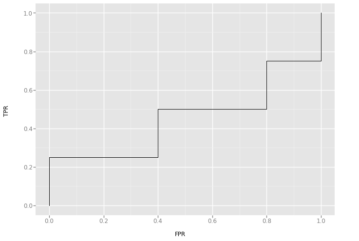

```
[[ 0.    0.  ]
 [ 0.25  0.  ]
 [ 0.25  0.2 ]
 [ 0.25  0.4 ]
 [ 0.5   0.4 ]
 [ 0.5   0.6 ]
 [ 0.5   0.8 ]
 [ 0.75  0.8 ]
 [ 0.75  1.  ]
 [ 1.    1.  ]]
[ 0.9  0.8  0.7  0.7  0.6  0.5  0.4  0.4  0.3]
```

```
0.45000000000000001
```

```python
##绘制ROC曲线
##obser和pred,其中pred是概率值表示，绘制ROC曲线
import pandas as pd
import numpy as np
from ggplot import *

def roc(obser,pred):

     ##定义求TP，FP的函数
    def TPR_FPR_cal(x,y,z=0):
        TP,FP,FN,TN = 0,0,0,0
        for i in range(len(x)):
            if (x[i] == 1) & (y[i] == 1):
                TP=TP+1
            if (x[i] == 0) & (y[i] == 0):
                TN=TN+1
            if (x[i] == 1) & (y[i] == 0):
                FN=FN+1
            if (x[i] == 0) & (y[i] == 1):
                FP=FP+1
        if z==0:
            return(TP/(TP+FN))
        if z ==1:
            return(FP/(FP+TN))

    ##定义计算auc函数
    def auc(array_2):
        FPR = array_2[:,1]
        TPR = array_2[:,0]
        auc_2 = 0
        for i in range(len(FPR)-1):
            temp = (FPR[i+1]-FPR[i])*(TPR[i]+TPR[i+1])
            auc_2 = auc_2+temp
        auc = auc_2/2
        return auc

    pred_sort = pred[np.argsort(-pred)]  ##这个真的是亮瞎了我的眼！！！！！！
    obser_sort = obser[np.argsort(-pred)]
    repo = np.ones((len(pred)+1,2)) ##第0列纵轴，第一列横轴,最后一行[1,1],所以要多一行，so，ROC曲线里面点比所给样本多一个。
    for i in (range(len(pred))):
        pred_01 = pred
        for j in range(len(pred)):
            if j<i:
                pred_01[j] = 1
            else:
                pred[j] = 0

        TPR = TPR_FPR_cal(obser_sort,pred_01,0)  ##TPR是纵轴
        FPR = TPR_FPR_cal(obser_sort,pred_01,1)  ##FPR是横轴
        repo[i] = [TPR,FPR]

    ##array to dataframe used in ggplot
    repo_df = pd.DataFrame(repo,columns = ["TPR","FPR"])
    print(ggplot(repo_df,aes(x='FPR',y="TPR"))+geom_line())
    print(repo)
    print(pred_sort)

    return(auc(repo))

roc(np.array([1,0,0,1,0,1,1,0,0]),np.array([0.3,0.7,0.8,0.4,0.5,0.9,0.7,0.4,0.6]))
```

```python
##带有代价敏感的错误率,cost_01表示把第0类预测为第1类,两者的和要等于2吧
def error_rate_cost(obser,pred,cost_0_1 = 1,cost_1_0 = 1):
    error_0_1 = sum(pred[obser==0]!=obser[obser==0])
    error_1_0 = sum(pred[obser==1]!=obser[obser==1])
    error = (cost_0_1*error_0_1)+(cost_1_0*error_1_0)
    return(error/len(obser))
arr1 = np.array([1,0,0,1,0])
arr2 = np.array([1,1,1,0,0])
print(error_rate_cost(arr1,arr2))
##我们认为把第0类预测为第1类的cost是0.0001，而把第一类预测为第0类cost为1.9999
print(error_rate_cost(arr1,arr2,cost_1_0 = 1.9999, cost_0_1 = 0.0001))
```

```
0.6
0.40002
```